# Data Analytics: Lab 2

Brendan Donnelly

October 2, 2020

### Lab 2 part 1

## Measures of central tendancy for EPI,DALY vars

```r
library(ggplot2)
EPI<-read.csv("/Users/donneb/Documents/DataAnalytics/EPI_data.csv")
summary(EPI$EPI)
```

```
##    Min. 1st Qu.  Median    Mean 3rd Qu.    Max.    NA's
##   32.10   48.60   59.20   58.37   67.60   93.50      68
```

```r
fivenum(EPI$EPI, na.rm = T)
```

```
## [1] 32.1 48.6 59.2 67.6 93.5
```

```r
summary(EPI$DALY)#stats
```

```
##    Min. 1st Qu.  Median    Mean 3rd Qu.    Max.    NA's
##    0.00   37.19   60.35   53.94   71.97   91.50      39
```

```r
fivenum(EPI$DALY, na.rm = T)
```

```
## [1]  0.000 36.955 60.350 72.320 91.500
```

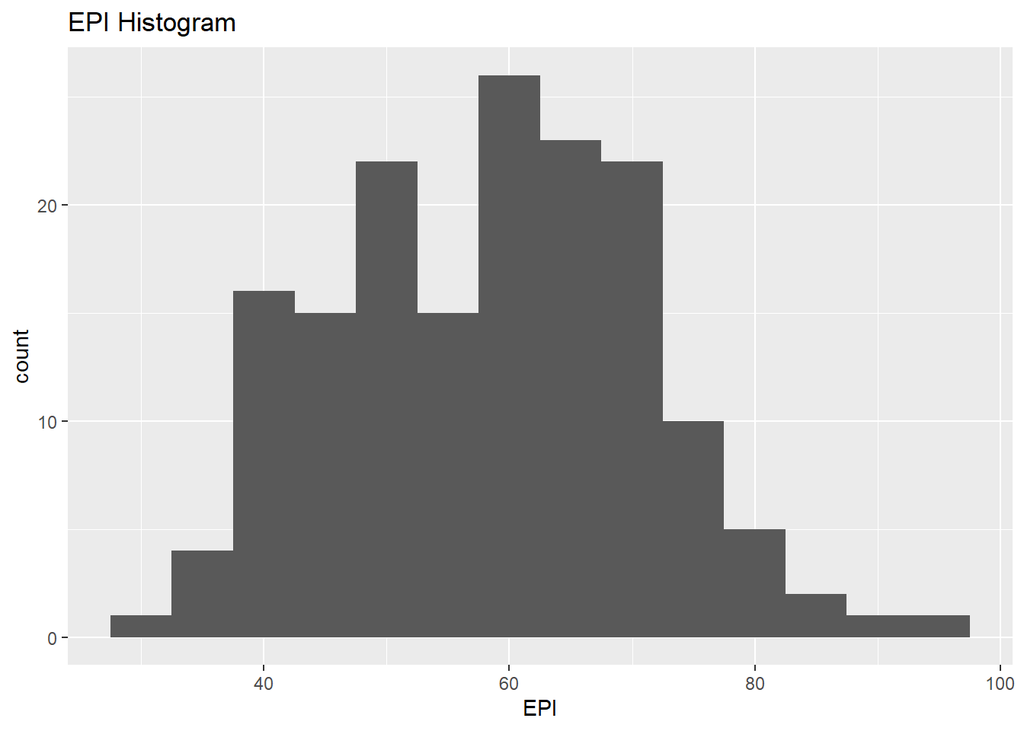

```r
# Histograms of both vars
histEPI<- ggplot(EPI, aes(x=EPI)) + geom_histogram(binwidth = 5, na.rm=TRUE)
histEPI +labs(title = "EPI Histogram")
```

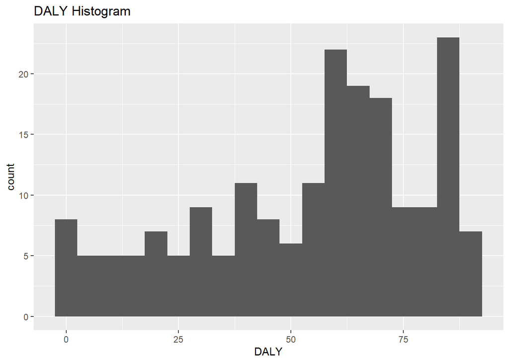

```r
histDALY<- ggplot(EPI, aes(x=DALY)) + geom_histogram(binwidth = 5, na.rm=TRUE, title = "Daly Histogram")
histDALY +labs(title = "DALY Histogram")
```

## Comparing ENVHEALTH and ECOSYSTEM’s Relationship

### boxplot,normal distribution plot comparing

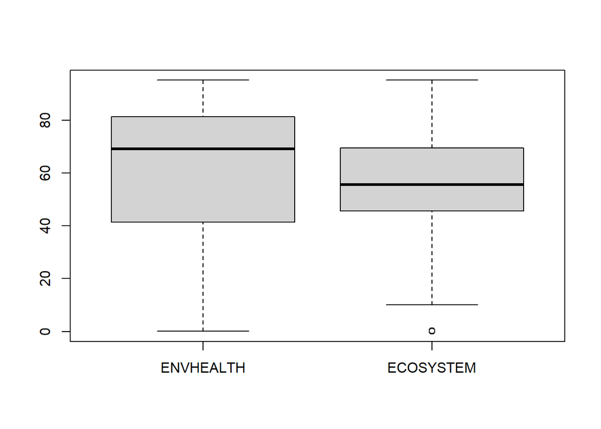

```r
#boxplot
boxplot(EPI$ENVHEALTH, EPI$ECOSYSTEM, names = c('ENVHEALTH','ECOSYSTEM'))
```

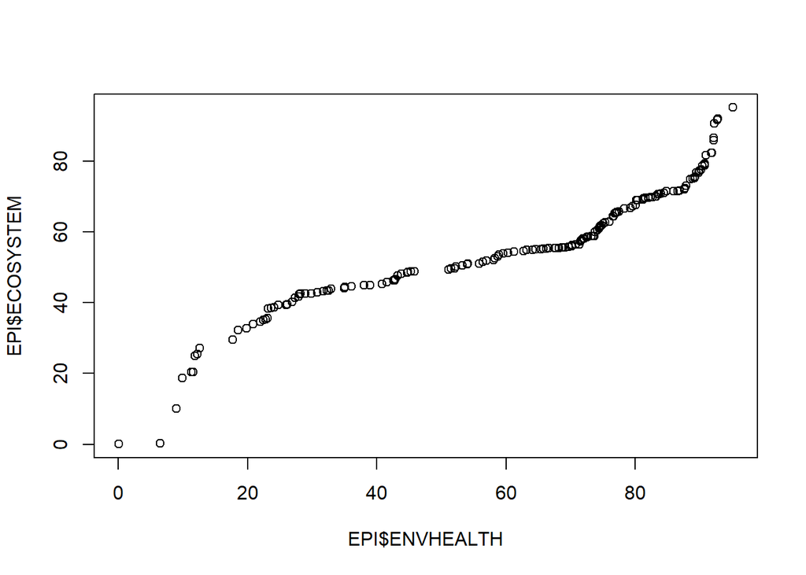

```r
#normal dist plots
qqplot(EPI$ENVHEALTH, EPI$ECOSYSTEM)
```

# Determining Most Important Factor in EPI Regression

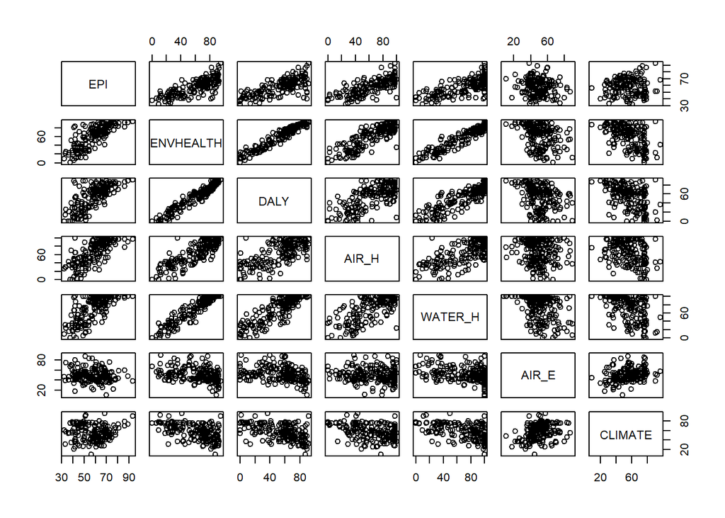

```r
#getting a feel for relationships
plot(EPI[c(14,15,17,18,19,20,26)])
```

## Linear and Least Squares ENVHEALTH

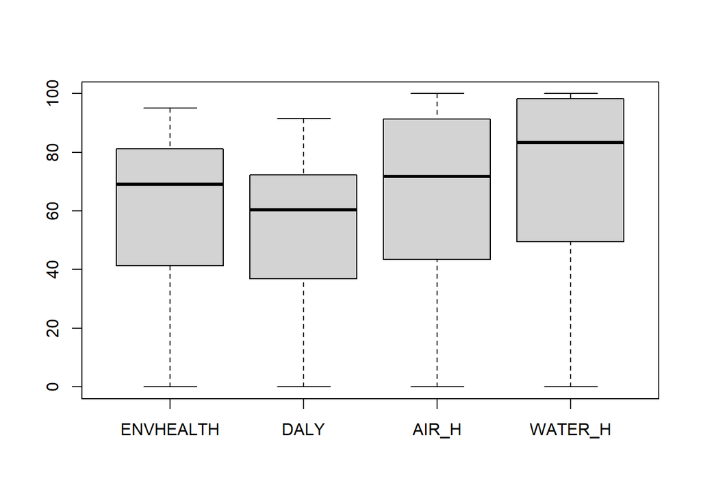

```r
ENVHEALTH <- EPI$ENVHEALTH
DALY <- EPI$DALY
AIR_H<- EPI$AIR_H
WATER_H<- EPI$WATER_H

# spread of all linear regression vars, w/ ENVHEALTh 1

boxplot(ENVHEALTH,DALY,AIR_H,WATER_H, names = c("ENVHEALTH", "DALY", "AIR_H", "WATER_H"))
```

```r
lmENVH<-lm(ENVHEALTH~DALY+AIR_H+WATER_H)
lmENVH
```

```
##
## Call:
## lm(formula = ENVHEALTH ~ DALY + AIR_H + WATER_H)
##
## Coefficients:
## (Intercept)         DALY        AIR_H      WATER_H
##  -2.673e-05    5.000e-01    2.500e-01    2.500e-01
```

```r
summary(lmENVH)
```

```
##
## Call:
## lm(formula = ENVHEALTH ~ DALY + AIR_H + WATER_H)
##
## Residuals:
##        Min         1Q     Median         3Q        Max
## -0.0072734 -0.0027299  0.0001145  0.0021423  0.0055205
##
## Coefficients:
##               Estimate Std. Error   t value Pr(>|t|)
## (Intercept) -2.673e-05  6.377e-04    -0.042    0.967
## DALY         5.000e-01  1.922e-05 26020.669   <2e-16 ***
## AIR_H        2.500e-01  1.273e-05 19645.297   <2e-16 ***
## WATER_H      2.500e-01  1.751e-05 14279.903   <2e-16 ***
## ---
## Signif. codes:  0 '***' 0.001 '**' 0.01 '*' 0.05 '.' 0.1 ' ' 1
##
## Residual standard error: 0.003097 on 178 degrees of freedom
##   (49 observations deleted due to missingness)
## Multiple R-squared:      1,  Adjusted R-squared:      1
## F-statistic: 3.983e+09 on 3 and 178 DF,  p-value: < 2.2e-16
```

```r
cENVH<-coef(lmENVH)
cENVH
```

```
##   (Intercept)          DALY         AIR_H       WATER_H
## -2.673362e-05  5.000401e-01  2.499968e-01  2.499781e-01
```

```r
DALYNEW<-c(seq(5,95,5))
AIR_HNEW<-c(seq(5,95,5))
WATER_HNEW<-c(seq(5,95,5))

NEW <-data.frame(DALYNEW,AIR_HNEW,WATER_HNEW)
pENV<- predict(lmENVH,NEW,interval = "pred")
cENV<- predict(lmENVH,NEW,interval = "conf")
```

#### DALY had the largest impact on the regression function compared to AIR_H, and WATER_H to determine ENVHEALTH. Predictions did not turn out well due to a resulting error in row counts in EPI vs. the NEW dataset will try to fix.

## regression on AIR_E

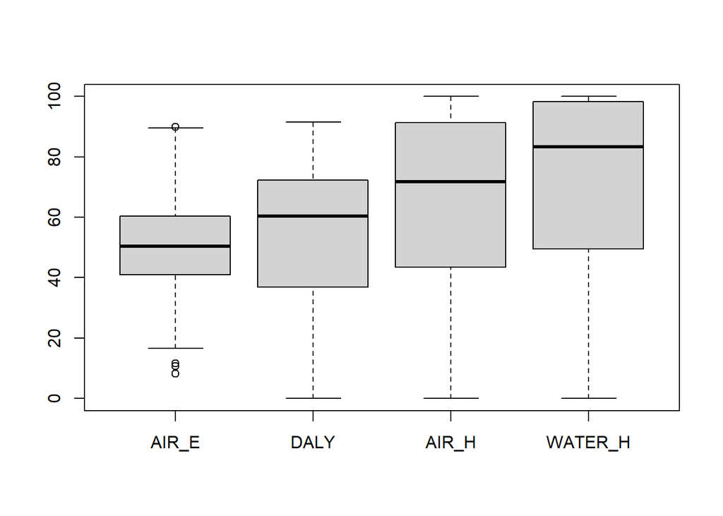

```r
DALYNEW<-c(seq(5,95,5))
AIR_HNEW<-c(seq(5,95,5))
WATER_HNEW<-c(seq(5,95,5))
NEW <-data.frame(DALYNEW,AIR_HNEW,WATER_HNEW)

AIR_E <- EPI$AIR_E

boxplot(AIR_E,DALY,AIR_H,WATER_H, names = c("AIR_E", "DALY", "AIR_H", "WATER_H"))
```

```r
lmAIR_E<-lm(AIR_E~DALY+AIR_H+WATER_H)
lmAIR_E
```

```
##
## Call:
## lm(formula = AIR_E ~ DALY + AIR_H + WATER_H)
##
## Coefficients:
## (Intercept)         DALY        AIR_H      WATER_H
##     59.2903      -0.1248       0.1686      -0.1798
```

```r
summary(lmAIR_E)
```

```
##
## Call:
## lm(formula = AIR_E ~ DALY + AIR_H + WATER_H)
##
## Residuals:
##     Min      1Q  Median      3Q     Max
## -32.708  -7.328  -1.739   8.117  38.182
##
## Coefficients:
##             Estimate Std. Error t value Pr(>|t|)
## (Intercept) 59.29025    2.55759  23.182  < 2e-16 ***
## DALY        -0.12482    0.07707  -1.620  0.10710
## AIR_H        0.16863    0.05104   3.304  0.00115 **
## WATER_H     -0.17982    0.07021  -2.561  0.01126 *
## ---
## Signif. codes:  0 '***' 0.001 '**' 0.01 '*' 0.05 '.' 0.1 ' ' 1
##
## Residual standard error: 12.42 on 178 degrees of freedom
##   (49 observations deleted due to missingness)
## Multiple R-squared:  0.1803, Adjusted R-squared:  0.1664
## F-statistic: 13.05 on 3 and 178 DF,  p-value: 9.654e-08
```

```r
cAIR_E<-coef(lmAIR_E)

pENV<- predict(lmAIR_E,NEW,interval = "prediction")
cENV<- predict(lmAIR_E,NEW,interval = "confidence")
```

#### In this regression the variable AIR_H had the largest pull compared to WATER_H and DALY in Determining AIR_E however the intercept had the strongest indicating a bad regression model

## regression on CLIMATE

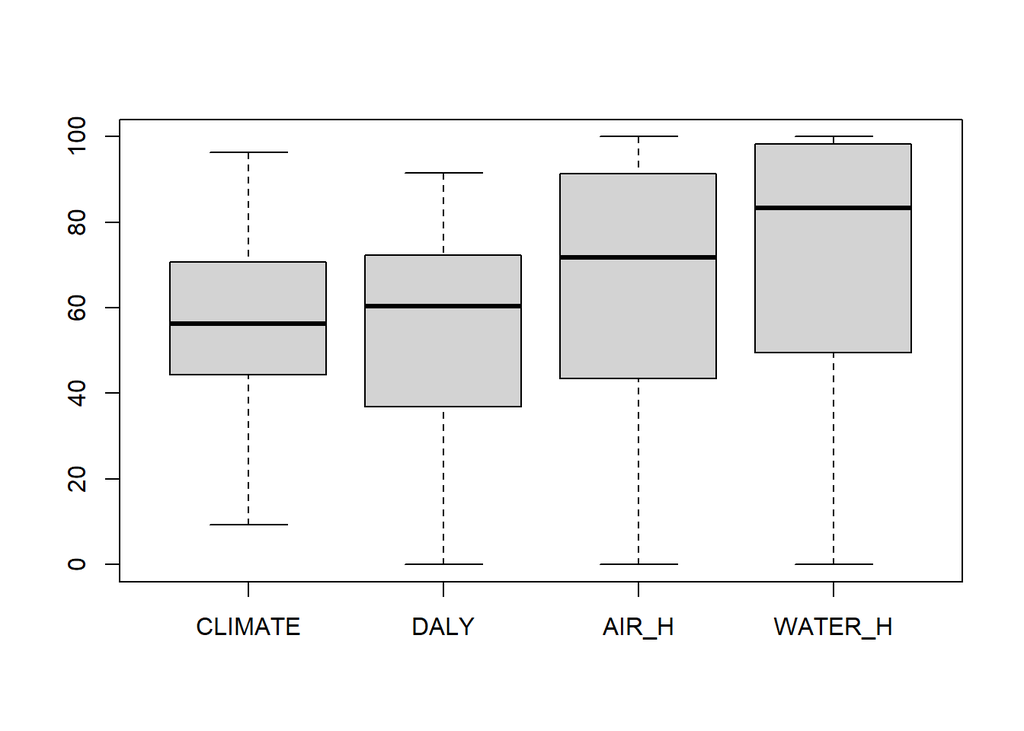

```r
CLIMATE <- EPI$CLIMATE
boxplot(CLIMATE,DALY,AIR_H,WATER_H, names = c("CLIMATE", "DALY", "AIR_H", "WATER_H"))
```

```r
lmCLIMATE<-lm(CLIMATE~DALY+AIR_H+WATER_H)
lmCLIMATE
```

```
##
## Call:
## lm(formula = CLIMATE ~ DALY + AIR_H + WATER_H)
##
## Coefficients:
## (Intercept)         DALY        AIR_H      WATER_H
##     75.3487      -0.1732       0.0181      -0.1538
```

```r
summary(lmCLIMATE)
```

```
##
## Call:
## lm(formula = CLIMATE ~ DALY + AIR_H + WATER_H)
##
## Residuals:
##     Min      1Q  Median      3Q     Max
## -37.578  -9.768   1.165   9.164  44.434
##
## Coefficients:
##             Estimate Std. Error t value Pr(>|t|)
## (Intercept) 75.34874    3.01412  24.999   <2e-16 ***
## DALY        -0.17323    0.09050  -1.914   0.0573 .
## AIR_H        0.01810    0.05919   0.306   0.7602
## WATER_H     -0.15385    0.08161  -1.885   0.0611 .
## ---
## Signif. codes:  0 '***' 0.001 '**' 0.01 '*' 0.05 '.' 0.1 ' ' 1
##
## Residual standard error: 14.15 on 168 degrees of freedom
##   (59 observations deleted due to missingness)
## Multiple R-squared:  0.255,  Adjusted R-squared:  0.2417
## F-statistic: 19.17 on 3 and 168 DF,  p-value: 9.704e-11
```

```r
cCLIMATE<-coef(lmCLIMATE)

pENV<- predict(lmCLIMATE,NEW,interval = "prediction")
cENV<- predict(lmCLIMATE,NEW,interval = "confidence")
```

#### In this regression the variables DALY,AIR_H,and WATER_H all were insignificant variables in the regression model to determine climate

# Lab 2 part 2

## Exercise 1: Regression

### Data Exploration

```r
mult_reg<-read.csv("/Users/donneb/Documents/DataAnalytics/dataset_multipleRegression.csv")
#EDA of data set
head(mult_reg)
```

```
##   YEAR ROLL UNEM HGRAD  INC
## 1    1 5501  8.1  9552 1923
## 2    2 5945  7.0  9680 1961
## 3    3 6629  7.3  9731 1979
## 4    4 7556  7.5 11666 2030
## 5    5 8716  7.0 14675 2112
## 6    6 9369  6.4 15265 2192
```

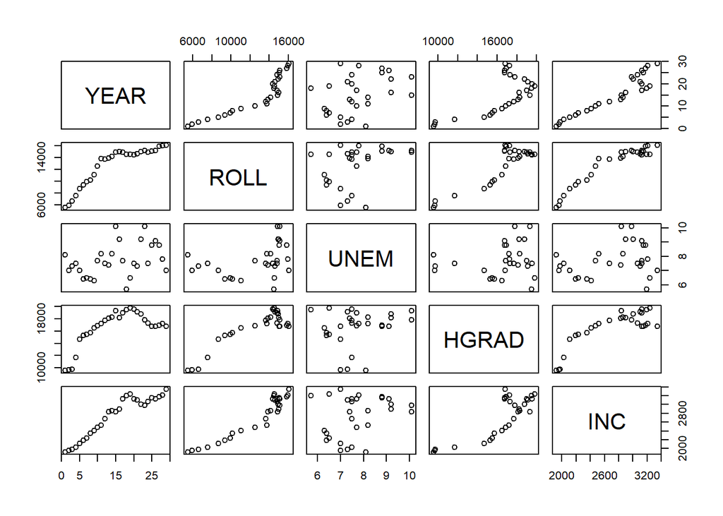

```r
plot(mult_reg[])
```

### regression model 1: Exploring regression model 1 factoring HGRAD, UNEM

```r
#Exploring regression model 1 factoring HGRAD, UNEM
lmROLL<- lm(ROLL~HGRAD+UNEM, data = mult_reg)
lmROLL
```

```
##
## Call:
## lm(formula = ROLL ~ HGRAD + UNEM, data = mult_reg)
##
## Coefficients:
## (Intercept)        HGRAD         UNEM
##  -8255.7511       0.9423     698.2681
```

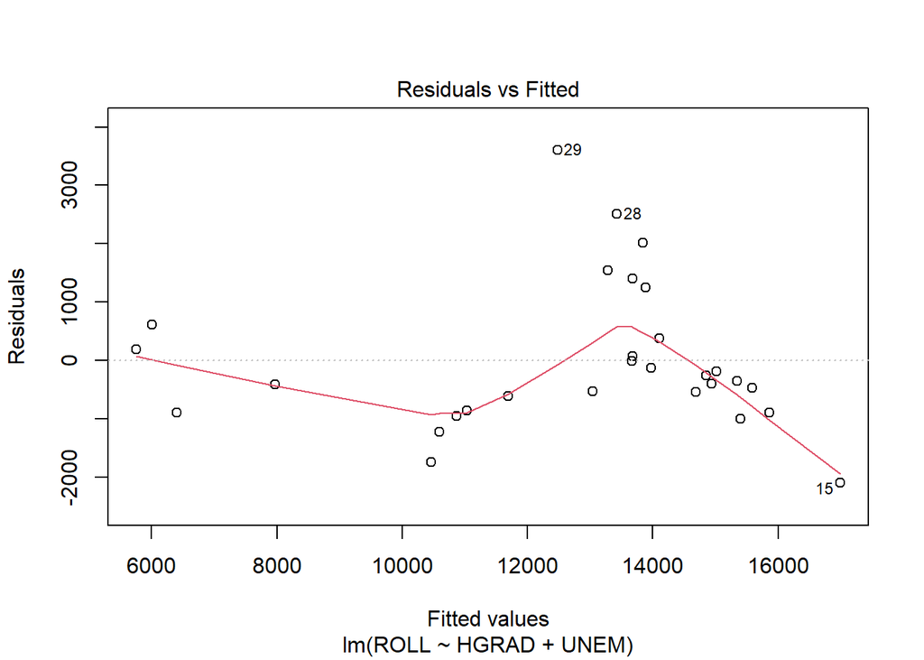

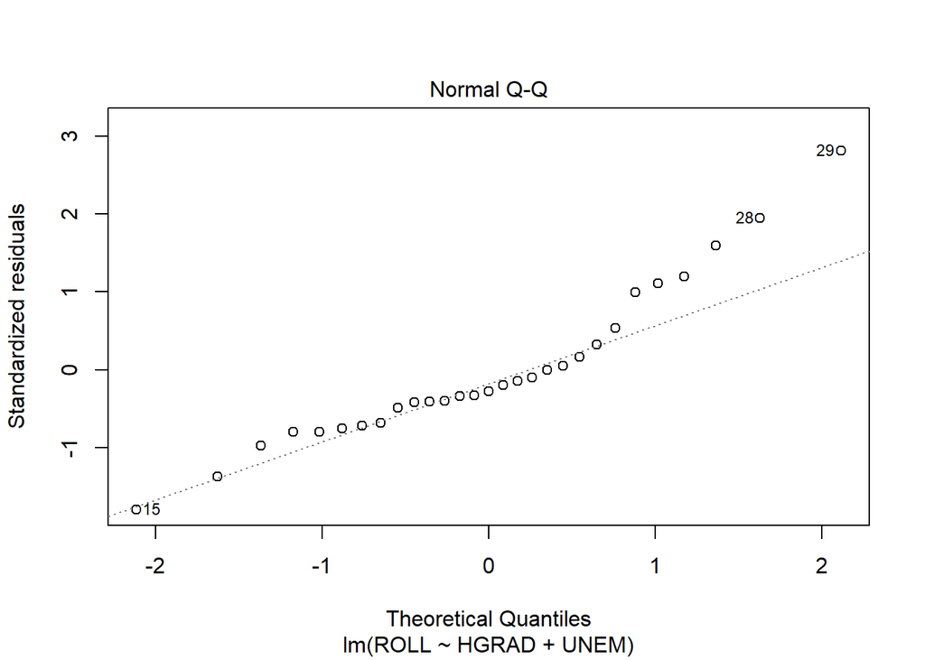

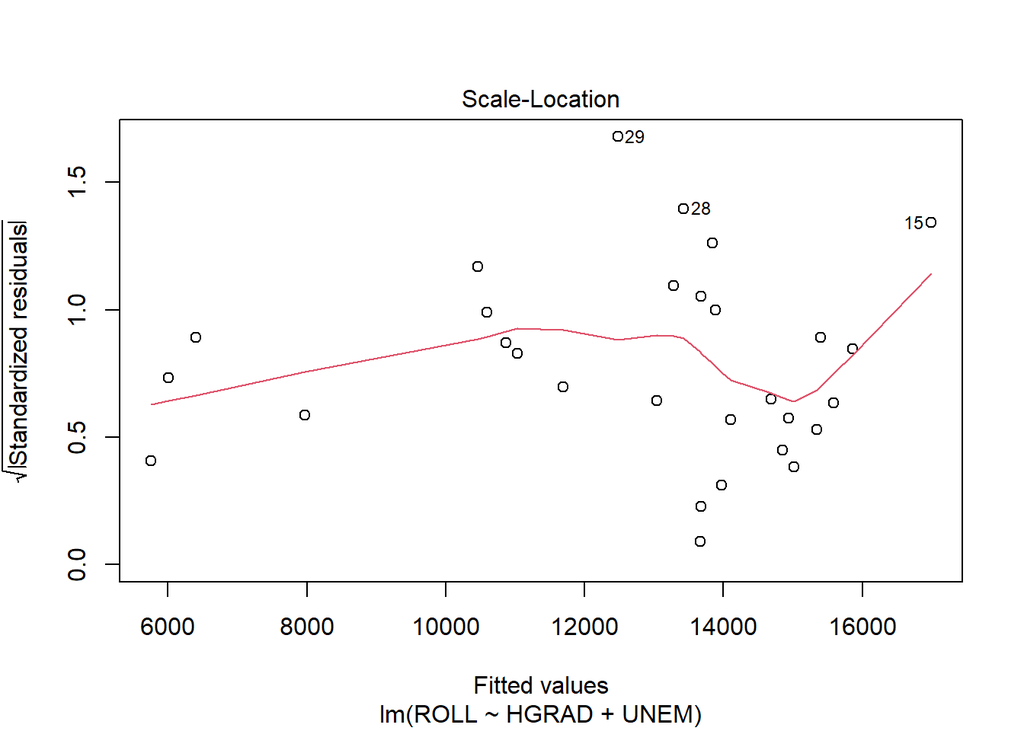

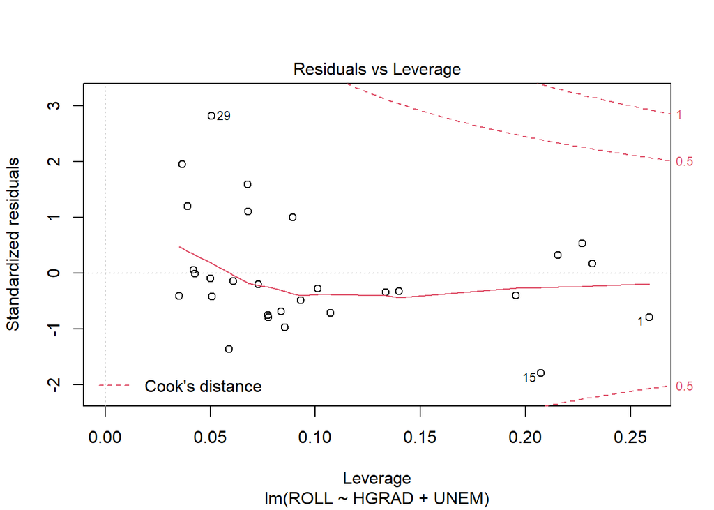

```r
#will only plot lm residuals and all for this example
plot(lmROLL)
```

```r
summary(lmROLL)
```

```
##
## Call:
## lm(formula = ROLL ~ HGRAD + UNEM, data = mult_reg)
##
## Residuals:
##     Min      1Q  Median      3Q     Max
## -2102.2  -861.6  -349.4   374.5  3603.5
##
## Coefficients:
##               Estimate Std. Error t value Pr(>|t|)
## (Intercept) -8.256e+03  2.052e+03  -4.023  0.00044 ***
## HGRAD        9.423e-01  8.613e-02  10.941 3.16e-11 ***
## UNEM         6.983e+02  2.244e+02   3.111  0.00449 **
## ---
## Signif. codes:  0 '***' 0.001 '**' 0.01 '*' 0.05 '.' 0.1 ' ' 1
##
## Residual standard error: 1313 on 26 degrees of freedom
## Multiple R-squared:  0.8489, Adjusted R-squared:  0.8373
## F-statistic: 73.03 on 2 and 26 DF,  p-value: 2.144e-11
```

```r
lmROLL$coefficients
```

```
##   (Intercept)         HGRAD          UNEM
## -8255.7510591     0.9422769   698.2681316
```

### prediction for model 1 w/ UNEM=7%, HGRAD=90,000

```r
#prediction 1 based on model 1
pred_nextyear1 <-predict(lmROLL, newdata=data.frame(HGRAD = 90000 , UNEM =.07 ))
pred_nextyear1
```

```
##        1
## 76598.04
```

### new model factoring HGRAD,UNEM,INC

```r
#Exploring regression model 1 factoring HGRAD, UNEM
lmROLL2<- lm(ROLL~HGRAD+UNEM+INC, data = mult_reg)
lmROLL2
```

```
##
## Call:
## lm(formula = ROLL ~ HGRAD + UNEM + INC, data = mult_reg)
##
## Coefficients:
## (Intercept)        HGRAD         UNEM          INC
##  -9153.2545       0.4065     450.1245       4.2749
```

```r
summary(lmROLL2)
```

```
##
## Call:
## lm(formula = ROLL ~ HGRAD + UNEM + INC, data = mult_reg)
##
## Residuals:
##      Min       1Q   Median       3Q      Max
## -1148.84  -489.71    -1.88   387.40  1425.75
##
## Coefficients:
##               Estimate Std. Error t value Pr(>|t|)
## (Intercept) -9.153e+03  1.053e+03  -8.691 5.02e-09 ***
## HGRAD        4.065e-01  7.602e-02   5.347 1.52e-05 ***
## UNEM         4.501e+02  1.182e+02   3.809 0.000807 ***
## INC          4.275e+00  4.947e-01   8.642 5.59e-09 ***
## ---
## Signif. codes:  0 '***' 0.001 '**' 0.01 '*' 0.05 '.' 0.1 ' ' 1
##
## Residual standard error: 670.4 on 25 degrees of freedom
## Multiple R-squared:  0.9621, Adjusted R-squared:  0.9576
## F-statistic: 211.5 on 3 and 25 DF,  p-value: < 2.2e-16
```

### prediction factoring per capita income (INC = 25,000)

```r
#prediction 1 based on model 1
pred_nextyear2 <-predict(lmROLL2, newdata=data.frame(HGRAD = 90000 , UNEM =.07, INC = 25000 ))
pred_nextyear2
```

```
##        1
## 134333.2
```

## Exercise 2

```r
# summary of data set
abalone<-read.csv("/Users/donneb/Documents/DataAnalytics/abalone.csv")
colnames(abalone) <- c("sex", "length", 'diameter', 'height', 'whole_weight', 'shucked_wieght', 'viscera_wieght', 'shell_weight', 'rings' )
summary(abalone)
```

```
##      sex                length         diameter          height
##  Length:4177        Min.   :0.075   Min.   :0.0550   Min.   :0.0000
##  Class :character   1st Qu.:0.450   1st Qu.:0.3500   1st Qu.:0.1150
##  Mode  :character   Median :0.545   Median :0.4250   Median :0.1400
##                     Mean   :0.524   Mean   :0.4079   Mean   :0.1395
##                     3rd Qu.:0.615   3rd Qu.:0.4800   3rd Qu.:0.1650
##                     Max.   :0.815   Max.   :0.6500   Max.   :1.1300
##   whole_weight    shucked_wieght   viscera_wieght    shell_weight
##  Min.   :0.0020   Min.   :0.0010   Min.   :0.0005   Min.   :0.0015
##  1st Qu.:0.4415   1st Qu.:0.1860   1st Qu.:0.0935   1st Qu.:0.1300
##  Median :0.7995   Median :0.3360   Median :0.1710   Median :0.2340
##  Mean   :0.8287   Mean   :0.3594   Mean   :0.1806   Mean   :0.2388
##  3rd Qu.:1.1530   3rd Qu.:0.5020   3rd Qu.:0.2530   3rd Qu.:0.3290
##  Max.   :2.8255   Max.   :1.4880   Max.   :0.7600   Max.   :1.0050
##      rings
##  Min.   : 1.000
##  1st Qu.: 8.000
##  Median : 9.000
##  Mean   : 9.934
##  3rd Qu.:11.000
##  Max.   :29.000
```

```r
str(abalone)
```

```
## 'data.frame':    4177 obs. of  9 variables:
##  $ sex           : chr  "M" "M" "F" "M" ...
##  $ length        : num  0.455 0.35 0.53 0.44 0.33 0.425 0.53 0.545 0.475 0.55 ...
##  $ diameter      : num  0.365 0.265 0.42 0.365 0.255 0.3 0.415 0.425 0.37 0.44 ...
##  $ height        : num  0.095 0.09 0.135 0.125 0.08 0.095 0.15 0.125 0.125 0.15 ...
##  $ whole_weight  : num  0.514 0.226 0.677 0.516 0.205 ...
##  $ shucked_wieght: num  0.2245 0.0995 0.2565 0.2155 0.0895 ...
##  $ viscera_wieght: num  0.101 0.0485 0.1415 0.114 0.0395 ...
##  $ shell_weight  : num  0.15 0.07 0.21 0.155 0.055 0.12 0.33 0.26 0.165 0.32 ...
##  $ rings         : int  15 7 9 10 7 8 20 16 9 19 ...
```

```r
summary(abalone$rings)
```

```
##    Min. 1st Qu.  Median    Mean 3rd Qu.    Max.
##   1.000   8.000   9.000   9.934  11.000  29.000
```

### grouping by age rings

```r
# age rings
abalone$rings <- as.numeric(abalone$rings)
abalone$rings <- cut(abalone$rings, br=c(-1,8,11,35), labels = c("young", 'adult', 'old'))
abalone$rings <- as.factor(abalone$rings)

summary(abalone$rings)
```

```
## young adult   old
##  1407  1810   960
```

# Copying dataset,removing non numeric for KNN, and normalizing

```r
aba<- abalone
aba$sex <-NULL

#  normalize the data using min max normalization
normalize <- function(x) {
  return ((x - min(x)) / (max(x) - min(x)))
}

aba[1:7] <- as.data.frame(lapply(aba[1:7], normalize))
summary(aba$shucked_wieght)
```

```
##    Min. 1st Qu.  Median    Mean 3rd Qu.    Max.
##  0.0000  0.1244  0.2253  0.2410  0.3369  1.0000
```

# Its KNN Time!

```r
ind <- sample(2, nrow(aba), replace=TRUE, prob=c(0.7, 0.3))

#test,train
KNNtrain <- aba[ind==1,]
KNNtest <- aba[ind==2,]

# set k to sqrt(2918) ~ 54.02 round up to 55
library(class)
KNNpred<- knn(train = KNNtrain[1:7], test = KNNtest[1:7], cl = KNNtrain$rings, k=55)
KNNpred
```

[output not shown]

[output cut: 89 more lines]

```r
table(KNNpred)
```

```
## KNNpred
## young adult   old
##   450   656   127
```